# PM 2

Felipe Dominguez

##### Semana 30/08 - 13/09

Objetivos de la semana:

- Terminar de asociar los ramos minimos para no incluirlos como exploratorios.
- Filtrar alumnos en que: año egreso colegio + 1 = año ingreso, y cualquier otro filtro que resulte útil.
  - Revisar archivos de Gert para ver los filtros usados.
- Listar sets de exploratorios que toman:
  - Analizar conjuntos por frecuencias.
  - Analizar cuáles sets son más “chapoteados”, y cuales son los óptimos.
- Encontrar alguna manera gráfica para representar la distribución temporal de semestres en que tomaron los exploratorios.
- Profundizar en la hipotesis H3: Depende de trayectorias educacionales (TE) que muestran desorientación.
  - H3.1: depende de TE que incluyen varios cursos exploratorios
  - H3.2: depende de TE que incluyen cursos de varios majors/minors

##### Datos sin filtrar majors ni minors

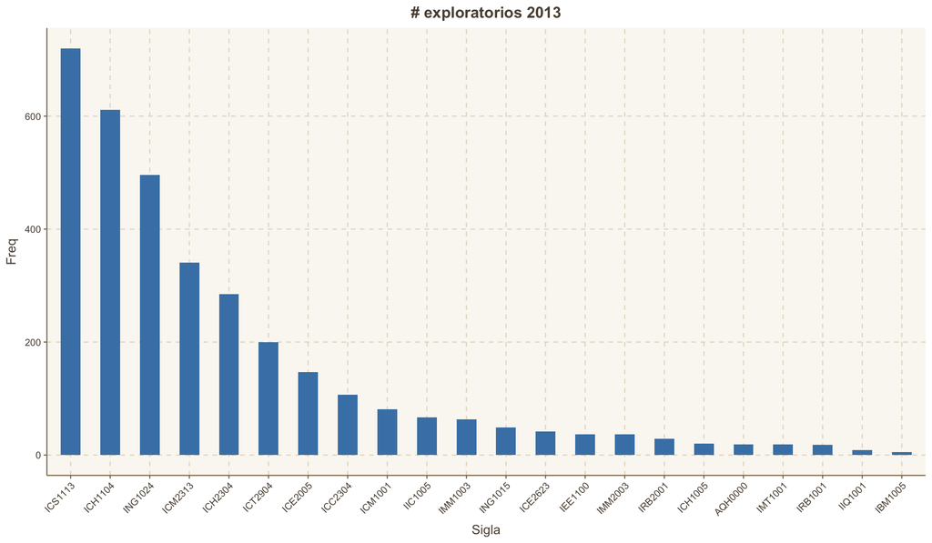

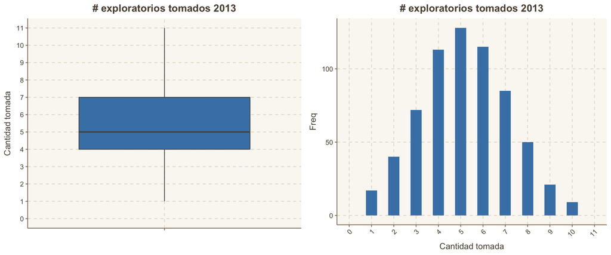

Para realizar un análisis con informacion más correcta, se linkearon los distintos exploratorios con sus respectivos majors y minors, y sólo se tomaron como cursos exploratorios aquellos que no estuvieran como cursos mínimos en la malla inscrita por el alumno.

##### Datos filtrados

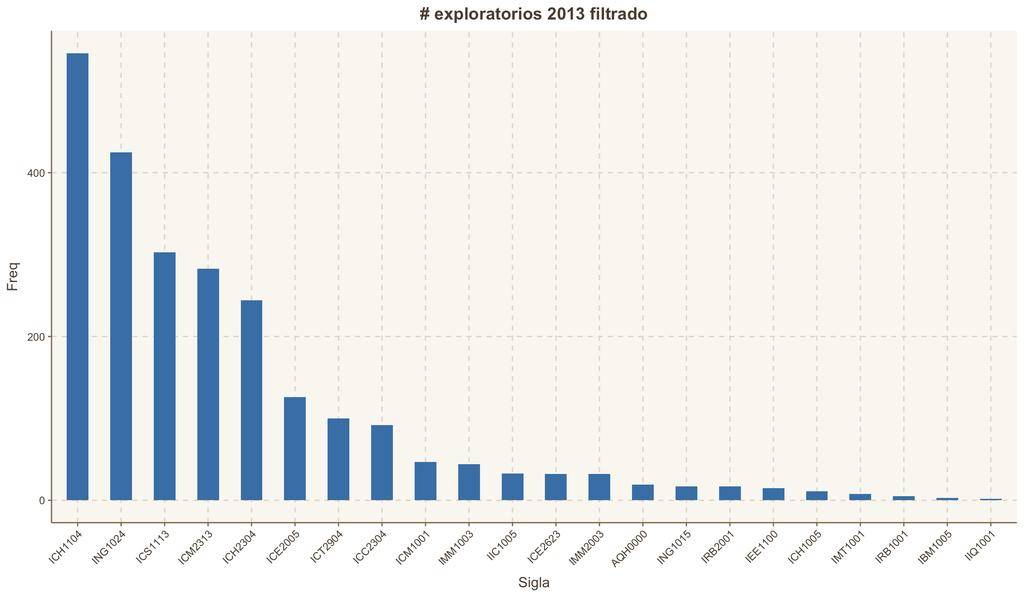

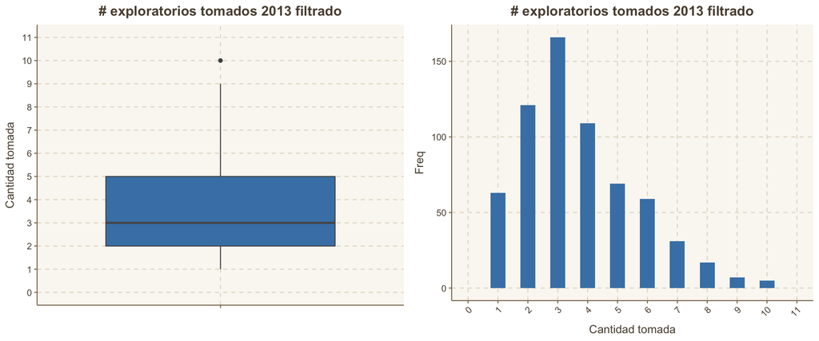

Se agarraron los alumnos que toman 3 exploratorios para analizar cuales son los grupos mas frecuentes.

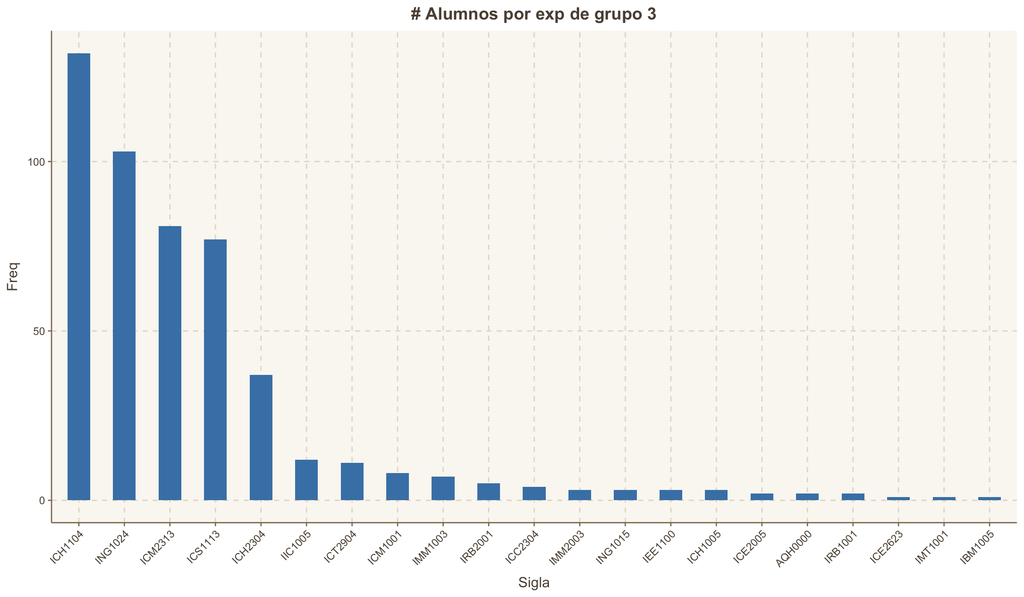